# Hypothesis Testing I

Arash Hatamirad, ahatamirad@gmail.com

9/1/2021

Cars.csv will be used for Exercise. The variables in the data are included below in the table. The variables in the data set are the following attributes of cars in the year 2004:

 Make – the auto manufacturer  
 Model – name of the vehicle  
 Type – SUV, sedan, sports, truck, or wagon  
 Origin – continent of the manufacturer; Europe, Asia, or USA  
 Invoice – price (dollars) that the manufacturer sends to the dealer upon delivery of the car  
 Horsepower – amount of the car’s power  
 MPG_City – miles per gallon (fuel efficiency) during city driving  
 MPG_Highway – miles per gallon during highway driving  
 Wheelbase – distance (inches) between the centers of the front and rear wheels  
 Length – distance (inches) from the nose to the tail of the car

## Exercise: Hypothesis Testing

Perform a hypothesis test of whether SUV has different horsepower than Truck, and state your conclusions

```r
# Read the CSV file
file.cars=read.csv("CARS.csv")
```

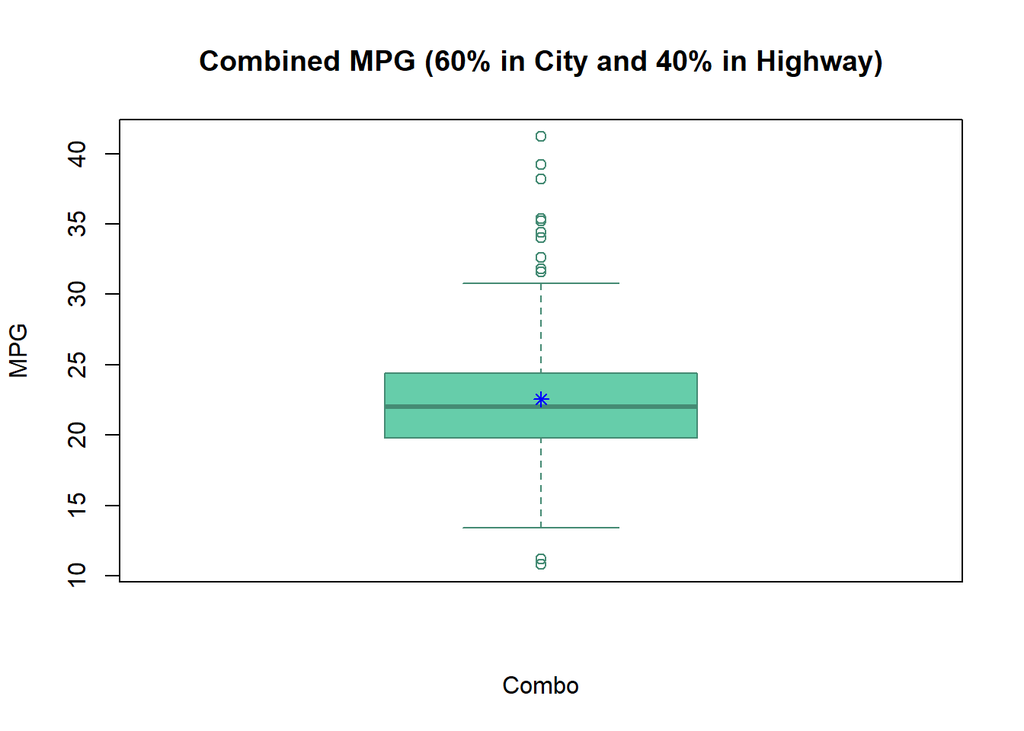

```r
# Make new MPG_Combo variable
MPG_Combo <- 0.6*file.cars$MPG_City +0.4*file.cars$MPG_Highway

#Add MPG_Combo variable to the end of tabale
file.cars.mpg_combo <- cbind(file.cars,MPG_Combo)



#Draw Box plot for the MPG_Combo variable and trim box plot
boxplot(file.cars.mpg_combo$MPG_Combo,main="Combined MPG (60% in City and 40% in Highway)",xlab="Combo",ylab="MPG",col = "aquamarine3",border ="aquamarine4")

#Point the mean value with a blue asterisk sign
points(mean(file.cars.mpg_combo$MPG_Combo,na.rm = TRUE),col="blue",pch=8)
```

#### Question (b):

- Specify null and alternative hypotheses.

#### Answer -:

- Null Hypothesis (H0):
- Two groups are from the same distribution (same median) it means SUV cars have similar horsepower as Truck Cars.
- Alternate Hypothesis (H1):
- One groups tends to have larger median value then the other group, it means SUV cars have different horsepower with Truck Cars.

#### Question (c):

- State the conclusion based on the test result

#### Answer -:

```r
# Filter SUV and Truck cars
cars.suv.truck <- file.cars %>%
  filter(Type == "SUV" | Type == "Truck")

# Run the wilcox Test
wilcox.test(Horsepower ~ Type, data=cars.suv.truck, exact=FALSE)
```

```
##
##  Wilcoxon rank sum test with continuity correction
##
## data:  Horsepower by Type
## W = 806.5, p-value = 0.3942
## alternative hypothesis: true location shift is not equal to 0
```